# Standortindikatoren

Städtevergleich

Author

Mongkol

Published

December 5, 2024

```r
data <- read_csv(here::here("daten/raw/ogd_standortindikatoren.csv"))
```

```r
library("gt")
library(ggalt)
```

# Einleitung

Das Projekt nutzt OGD Daten des Kantons Zürichs. In den Daten sind Indikatoren zur Messung der Standortattraktivität zwischen den Städten Zürich, München, Amsterdam, Stockholm, London sowie Dublin erfasst. In der heutigen Weltordnung, dienen Standortindikatoren als Vergleichsgrössen, um die “Wettbewerbsfähigkeit” von zu untersuchenden Beobachtungseinheiten miteinander zu vergleichen (Benchmarking).

## Daten

Die Daten stammen vom OGD [Datensatz](https://www.zh.ch/de/politik-staat/statistik-daten/datenkatalog.html#/datasets/2423@awi-kanton-zuerich) des Kantons Zürich.

Zur Beurteilung der Standortattraktivität werden beispielweise Faktoren wie die Attraktivität für internationale Talente, Erwerbstätigenquote, Rekrutierungsschwierigkeiten, Anteil Top-Universitäten pro Einwohner, Anteil Bevölkerung mit Tertiärabschlus, Jugendarbeitslosigkeit beigezogen.

## Analyseziele

Ziel ist es, den Zusammenhang zwischen Altersstruktur der Bevölkerung in den Städten und deren Erwerbstätigenquote zu untersuchen. Wir gehen davon aus, dass eine Stadt mit einem hohen Anteil an 15 bis 64 Jährigen entsprechend auch eine hohe Erwerbstätigenquote ausweist.

# Daten Aufbereitung

Bevor ich die Spalten in numerische Werte umwandel kann, muss ich die Zeilen mit fehlenden Werten eliminieren. Dadurch verliere ich 2 Beobachtungen und habe statt 45 Beobachtungen nur noch 43.

```r
# Zeilen mit NA in irgendeiner Spalte entfernen
data <- na.omit(data)
```

```r
data$London <- as.numeric(data$London)
data$Stockholm <- as.numeric(data$Stockholm)
data$Dublin <- as.numeric(data$Dublin)
```

```r
# Zuerst die Daten ins lange Format bringen
data_long <- data %>%  pivot_longer(
  cols = c(Zuerich, London, Amsterdam, Muenchen, Dublin, Stockholm),
  names_to = "Stadt",
  values_to = "Wert")

# Nun das lange Format zurück ins breite Format transformieren datensatz_wide <- datensatz_long %>%  pivot_wider(names_from = Indikatoren, values_from = Wert)
```

```r
data_select <- data_long |>
  select(Messjahr, Stadt, Indikator, Wert)
```

# Ergebnisse

Die Grafik Figure 1 vergleicht die im Datensatz vorhandenen Städte hinsichtlich ihrer Bevölkerungsstruktur. Dabei zeigt sich, dass die Stadt Zürich mit 57.8 Prozent den grössten Anteil an 15 bis 64 Jährigen aufweist, wobei Stockholm nur auf einen Anteil von 28.8 Prozent kommt (siehe Table 1). Infolgedessen wäre gemäss unserer These davon auszugehen, dass die Stadt Zürich die höchste Erwerbstätigenquote und die Stadt Stockholm die tiefste Erwerbstätigenquote aufweisen. Figure 2 bestätigt unsere Annahme mit Blick auf die Stadt Zürich. Jedoch weist nicht Stockholm die tiefste Erwerbstätigenquote aus, sondern Dublin, die mit 52.4 Prozent den zweithöchsten Anteil an erwerbsfähigen Bevölkerung aufweist.

## Daten Visualisierung

```r
Anteil_Bevoelkerung <- data_select |>
  filter(Indikator == "Anteil der Bevölkerung zwischen 15 und 64 Jahren") |>
  arrange(Wert)

erwerbstätigenquote <- data_select |>
  filter(Indikator == "Erwerbstätigenquote") |>
  arrange(Wert)
```

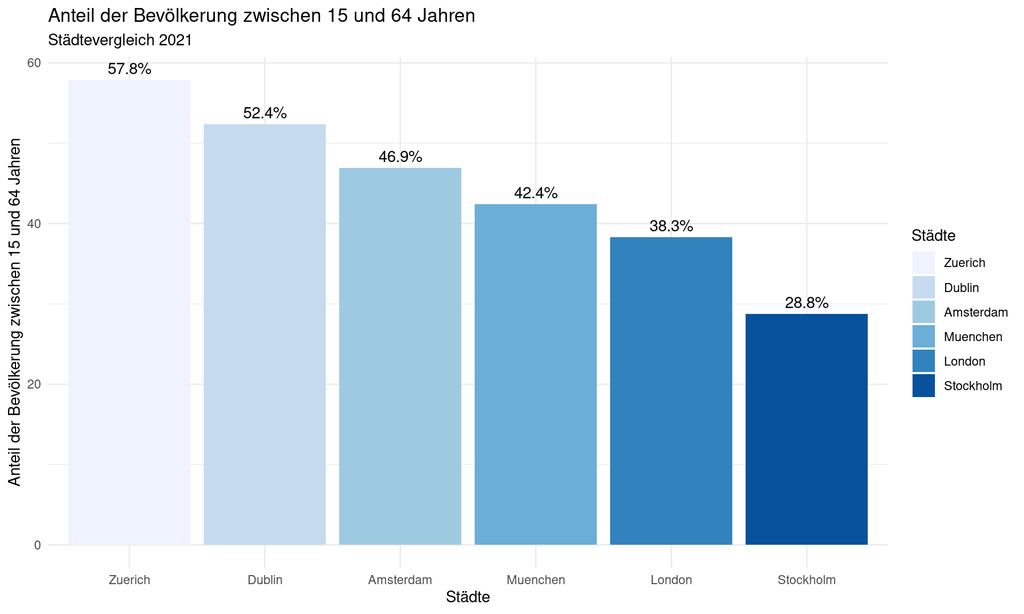

Figure 1: Anteil der Bevölkerung zwischen 15 und 64 Jahren

```r
ggplot(data = Anteil_Bevoelkerung,
       mapping = aes(x = reorder(Stadt, -Wert),
                     y = Wert,
                     fill = reorder(Stadt, -Wert))) +  # Änderung hier
  geom_col(position = "dodge") +
  geom_text(aes(label = paste0(round(Wert, 1), "%")),
            position = position_dodge(width = 0.9),
            vjust = -0.5) +
  labs(title = "Anteil der Bevölkerung zwischen 15 und 64 Jahren",
       subtitle = "Städtevergleich 2021",
       y = "Anteil der Bevölkerung zwischen 15 und 64 Jahren",
       x = "Städte",
       fill = "Städte") +
  scale_fill_brewer(palette = "Blues") +
  guides(fill = guide_legend(reverse = FALSE)) +  # Neue Zeile
  theme_minimal()
```

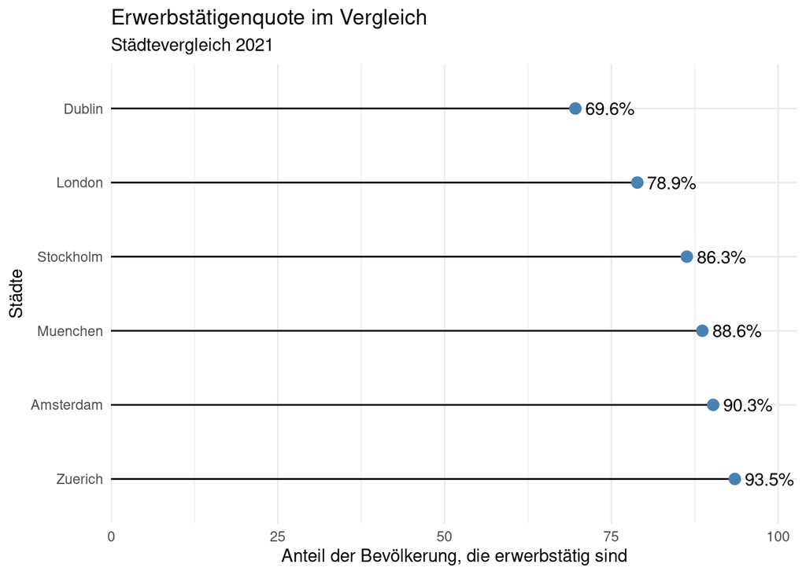

Figure 2: Anteil der Bevölkerung, die erwerbstätig sind

```r
ggplot(erwerbstätigenquote, aes(x = reorder(Stadt, -Wert), y = Wert)) +
  geom_lollipop(point.colour = "steelblue", point.size = 3) +
  geom_text(aes(label = paste0(round(Wert, 1), "%")), hjust = -0.2) +
  labs(title = "Erwerbstätigenquote im Vergleich",
       subtitle = "Städtevergleich 2021",
       y = "Anteil der Bevölkerung, die erwerbstätig sind",
       x = "Städte") +
  theme_minimal() +
  coord_flip() +
  scale_y_continuous(expand = expansion(mult = c(0, 0.1)))
```

```r
Anteil_Bevoelkerung <- Anteil_Bevoelkerung |>
  rename(Median = Wert)
```

## Tabelle

```r
Anteil_Bevoelkerung |>
  gt() |>
  tab_header(title = "Anteil der Bevölkerung: Vergleich der Städte"
)
```

Table 1: Anteil der Bevölkerung: Vergleich der Städte

Anteil der Bevölkerung: Vergleich der Städte

| Messjahr | Stadt | Indikator | Median |
| --- | --- | --- | --- |
| 2021 | Stockholm | Anteil der Bevölkerung zwischen 15 und 64 Jahren | 28.75067 |
| 2021 | London | Anteil der Bevölkerung zwischen 15 und 64 Jahren | 38.28370 |
| 2021 | Muenchen | Anteil der Bevölkerung zwischen 15 und 64 Jahren | 42.38388 |
| 2021 | Amsterdam | Anteil der Bevölkerung zwischen 15 und 64 Jahren | 46.91196 |
| 2021 | Dublin | Anteil der Bevölkerung zwischen 15 und 64 Jahren | 52.38022 |
| 2021 | Zuerich | Anteil der Bevölkerung zwischen 15 und 64 Jahren | 57.84353 |

```r
library(openxlsx)

write_csv(x = data_select,
          here::here("daten/processed/standortindikatoren_überarbeitet.csv"))

write.xlsx(data_select, here::here("daten/processed/standortindikatoren.xlsx"))
```

# Schlussfolgerung

Der Anteil an der erwerbsfähigen Bevölkerung nach Alter (gemessen am Altersrange von 15 bis 64 Jahren) erklärt alleine nicht die Höhe der Erwerbstätigenquote. Entsprechend ist davon auszugehen, dass noch andere Faktoren einen Einfluss auf die Höhe der Erwerbstätigenquote haben. Diese kleine Studie dient als Grundlage und Motivation, um weitere Erkenntnisse über Faktoren zu gewinnen, die einen Einfluss auf die Erwerbstätigenquote von Städten haben. Leider ist die Datenqualität und Beschreibung der Daten nicht nachvollziehbar bzw. fragwürdig. So ist der geringe Anteil der Bevölkerung von 15 bis 64 Jährigen bei der Stadt Stockholm (28.8 Prozent) nicht nachvollziehbar.